# 2 Introduction to Bayesian Thinking

===================================================

I ll try to use the notebook for “Bayesian Computation with R”

## 2. Introduction to Bayesian Thinking

Basics of Bayesian inferential approach.

```r
library("LearnBayes")
```

Problem: what is % of collage students in America get at least 8h sleep? -> $p$: the %, we want to learn p!!

Decide the prior of ‘p’ -> she decided $p = 0.3$ but $p \in [0, .5]$ is plausible.

A sample of 27 students are taken: 11 had over 8h sleep. What she wants to know

- Estimating $p$ after the observation
- Num of students that take at least 8h sleep if a new 20 sample is taken

$g(p)$: distribution of $p$. Then the likelihood is

$$L(p) \propto p^s(1-p)^f$$
where $s$ is the number of success (8h sleep) while $f$ is the failure. From Bayes’ rule, the posterior is
$$g(p|\text{data}) \propto g(p) L(p)$$

See the prior distribution

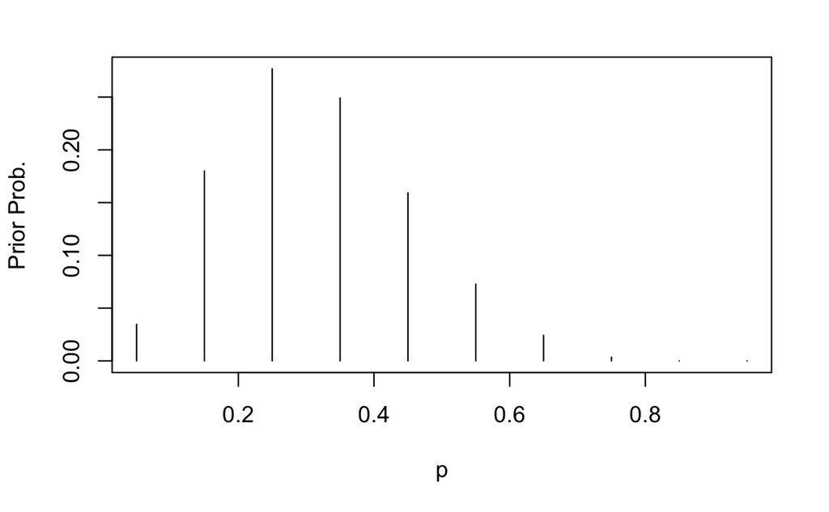

```r
p=seq(.05, .95, by = 0.1) # possible val for $p$
prior = c(1, 5.2, 8, 7.2, 4.6, 2.1, 0.7, 0.1, 0.0, 0.0) # prior to the p
prior = prior/sum(prior) # conver to the prob
plot(p, prior, type="h", ylab = "Prior Prob.")
```

```r
data = c(11,16)  # num of success and failure
post = pdisc(p, prior = prior, data = data)  # compute posterior from LearnBayes
round(cbind(p, prior, post), 2)
```

```
         p prior post
 [1,] 0.05  0.03 0.00
 [2,] 0.15  0.18 0.00
 [3,] 0.25  0.28 0.13
 [4,] 0.35  0.25 0.48
 [5,] 0.45  0.16 0.33
 [6,] 0.55  0.07 0.06
 [7,] 0.65  0.02 0.00
 [8,] 0.75  0.00 0.00
 [9,] 0.85  0.00 0.00
[10,] 0.95  0.00 0.00
```

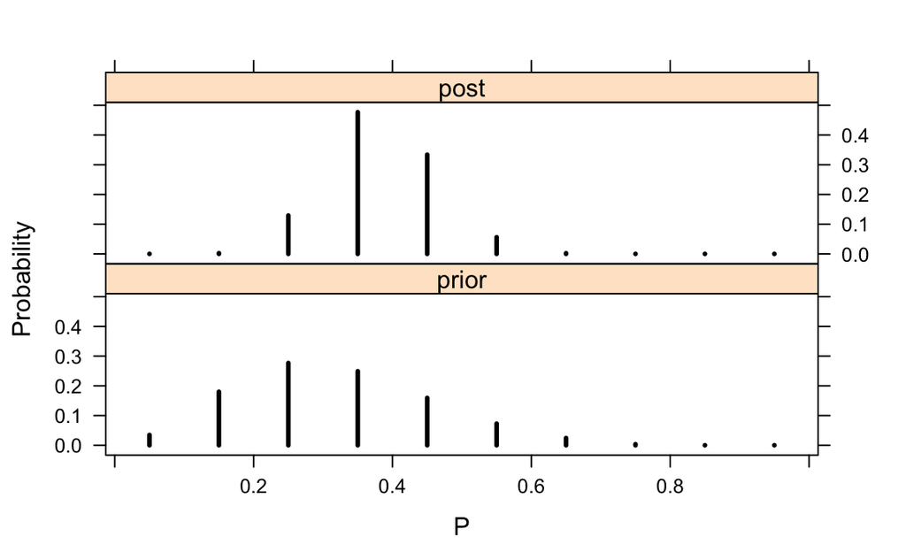

```r
library(lattice)  # for plotting nicely
PRIOR = data.frame("prior",p,prior)
POST =  data.frame("post",p,post)
names(PRIOR) = c("Type", "P", "Probability")
names(POST) = c("Type", "P", "Probability")
data = rbind(PRIOR,POST)
xyplot(Probability~P|Type, data = data, layout=c(1,2), type="h", lwd=3,col="black")
```

### 2.4 Using a Bata prior

She thinks:

- $p$ can be larger or smaller than .3 equally likely (50% quantile is 0.3)
- 90% confindent that $p \leq 0.5$ (90% quantile is 0.5)

Express by the beta dist.

```r
quantile1= list(p=.5, x=.3)
quantile2 = list(p=.9, x=.5)
beta.select(quantile1, quantile2) # select the beta dist with the quantiles
```

```
[1] 3.26 7.19
```

We know that $a = 3.26, b = 7.19$. After observing data, the posterior will be
$$g(p|\text{data}) \propto p^{a+s-1}(1-p)^{b+f-1}$$
Since prior, likelihood, and posterior are beta family,

```r
a = 3.26
b = 7.19
s = 11
f = 16
curve(dbeta(x, a+s, b+f), from=0, to=1, xlab = "p", ylab = "Density",lty=1,lwd=4)  # posterior
curve(dbeta(x, s+1, f+1), add=TRUE,lty=2,lwd=4) # likelihood
```

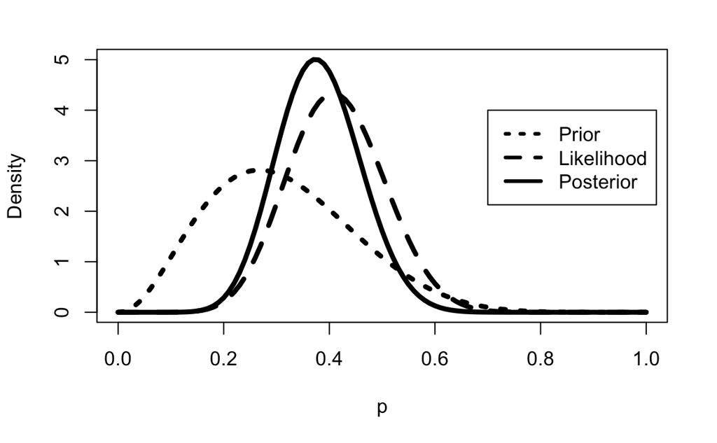

```r
curve(dbeta(x, a, b), add=TRUE,lty=3,lwd=4)  # prior
legend(.7,4,c("Prior","Likelihood","Posterior"),lty=c(3,2,1),lwd=c(3,3,3))
```

```r
1-pbeta(0.5, a+s, b+f)
```

```
[1] 0.0690226
```

**Question** *What is 90% credible interval for $p$*

```r
qbeta(c(0.05,0.95), a+s, b+f)
```

```
[1] 0.2555267 0.5133608
```

#### Do the same things by a simulation

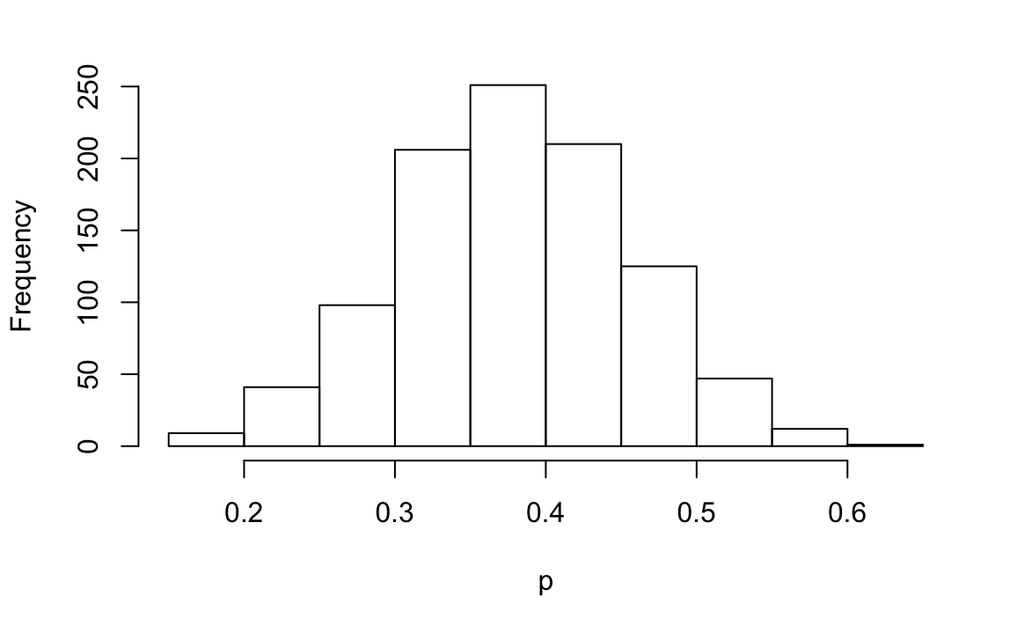

```r
ps = rbeta(1000, a+s, b+f)  # generate 1000 samples from the posterior
hist(ps, xlab = "p", main = "")
```

```r
sum(ps >= 0.5)/1000  # probabiltity of p is larger than 0.5
```

```
[1] 0.06
```

```r
quantile(ps,c(0.05,0.95))  # quantile of 5% and 95%
```

```
       5%       95%
0.2502848 0.5128701
```

Results are similar to the theoretical ones.

### 2.5 Using a Histogram Prior

Better to work with more general prior -> histogram.

**“Brute-force” method for summarizing posterior $g(p)$**

- define grid of $p$
- compute likelihood and the prior on the gird
- make them probability distributions (normalization)
- take random sample (approx sample from the posterior)

She wants to make a grid as:
$$(0, 0.1),(0.1, 0.2), \ldots, (0.9, 1)$$
and assign prob for each interval.

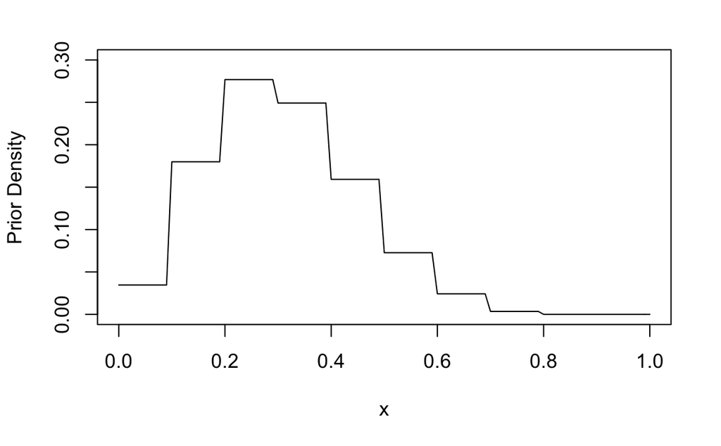

```r
midpt = seq(0.05, 0.95, by=0.1)  # mid value for each int
prior = c(1, 5.2, 8, 7.2, 4.6, 2.1, 0.7, 0.1, 0.0, 0.0) # prior to the p ("importance")
prior = prior/sum(prior) # conver to the prob
curve(histprior(x, midpts = midpt, prior), from=0, to=1, ylab = "Prior Density", ylim =c(0,.3))  # step function of the prior
```

Compute the posterior

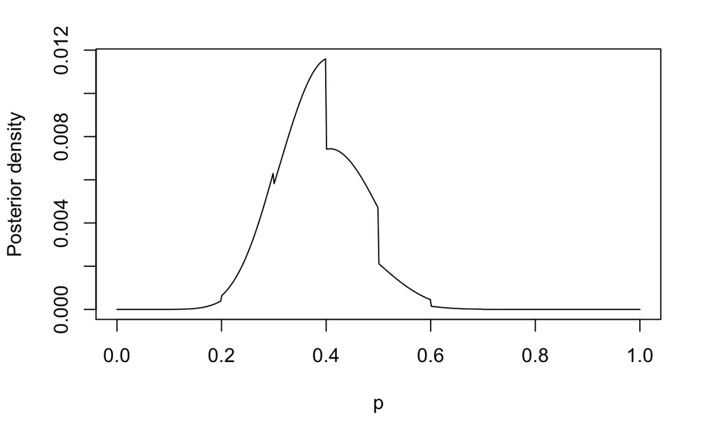

```r
p = seq(0,1, length=500)
post = histprior(p, midpt, prior) * dbeta(p, s+1, f+1) # post = prior*likelihood
post = post/sum(post)  # normalize
plot(p,post, type="l",xlab = "p", ylab = "Posterior density")
```

Finally, taking samples from the posterior

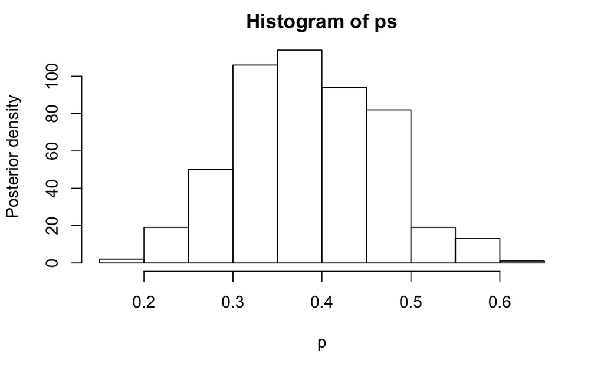

```r
ps = sample(p, replace = TRUE, prob=post)  # replace=TRUE allows duplication
hist(ps, xlab="p", ylab = "Posterior density")
```

### 2.6 Prediction

**Question** *Number of heavy sleepers $\tilde{y}$ in a new sample of $m=20$ students?*

The predictive density of $\tilde{y}$ is gven by:
$$f(\tilde{y}) = \int f(\tilde{y}|p)g(p)dp$$

If $g$ is prior, $f$ is *prior predictive density*, whereas if $g$ is posterior, $f$ is *posterior predictive density*.

Suppose - $\{p_i\}$: possible val of the proportion $p$ w.p. $\{g(p_i)\}$ - $f_B(y|n,p)$: Binomial density given sample size $n$ and proportion $p$, ie:
$$f_B(y|n,p) = {n\choose y} p^y(1-y)^{n-y}, y = 0,\ldots,n.$$
Then, the predictive density is:
$$f(\tilde{y}) = \sum f_B(\tilde{y}|m,p_i)g(p_i)$$
`pdiscp` in `LearnBayes`: useful to compute the predictive probabilities.

```r
p = seq(0.05,0.95, by = .1)
prior = c(1, 5.2, 8, 7.2, 4.6, 2.1, 0.7, 0.1, 0.0, 0.0) # prior to the p ("importance")
prior = prior/sum(prior) # conver to the prob
m = 20; ys = 0:20 # sample size and the possible value of y
pred = pdiscp(p, prior, m, ys) # prior predictive density
round(cbind(0:20, pred),3)  # predicted prob for each possible y
```

```
          pred
 [1,]  0 0.020
 [2,]  1 0.044
 [3,]  2 0.069
 [4,]  3 0.092
 [5,]  4 0.106
 [6,]  5 0.112
 [7,]  6 0.110
 [8,]  7 0.102
 [9,]  8 0.089
[10,]  9 0.074
[11,] 10 0.059
[12,] 11 0.044
[13,] 12 0.031
[14,] 13 0.021
[15,] 14 0.013
[16,] 15 0.007
[17,] 16 0.004
[18,] 17 0.002
[19,] 18 0.001
[20,] 19 0.000
[21,] 20 0.000
```

If we use Beta prior, we can copmute the predictive density analitically. Suppose one make the prior with $beta(a,b)$, then
$$f(\tilde{y}) = \int f_B(\tilde{y}|m,p)g(p)dp
= {n\choose y} \frac{B(a+\tilde y, b+m - \tilde y)}{B(a,b)}, \tilde y = 0,\ldots,m,$$

`pbetap` can compute the predictive probability with beta distribution.

```r
ab = c(3.26, 7.19)  # reuse the previous result of her belief
m = 20; ys = 0:20
pred_beta = pbetap(ab, m, ys) # predictive prob
round(cbind(0:20, pred_beta),3)  # predicted prob for each possible y
```

```
         pred_beta
 [1,]  0     0.018
 [2,]  1     0.045
 [3,]  2     0.072
 [4,]  3     0.095
 [5,]  4     0.108
 [6,]  5     0.114
 [7,]  6     0.111
 [8,]  7     0.102
 [9,]  8     0.088
[10,]  9     0.073
[11,] 10     0.057
[12,] 11     0.043
[13,] 12     0.030
[14,] 13     0.020
[15,] 14     0.012
[16,] 15     0.007
[17,] 16     0.004
[18,] 17     0.002
[19,] 18     0.001
[20,] 19     0.000
[21,] 20     0.000
```

```r
plot(ys, pred, type="l",xlab = "ys", ylab = "Prior predicteve probability",lty=1, col="red")
lines(ys, pred_beta, type="l", lty=2,col="blue")
```

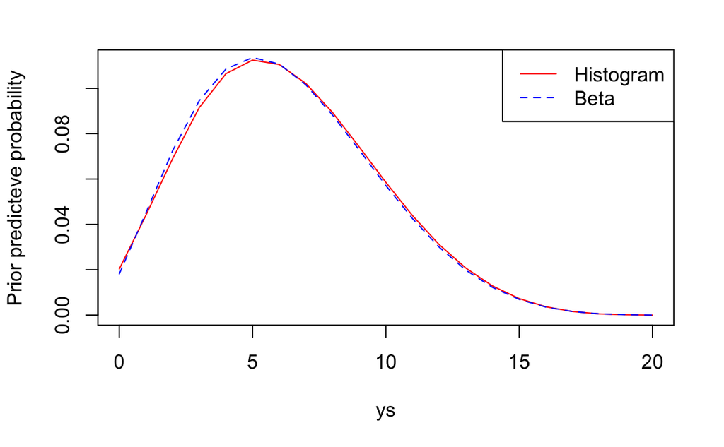

```r
legend("topright",c("Histogram","Beta"), col= c("red", "blue"), lty=c(1,2 ))
```

Compute the predictive density form *any* prior -> **simulation**. Here is the step:

- simulate $p^*$ from $g(p)$
- simulate $\tilde y$ from the binomial $f_B(\tilde y|p^*)$

We again use the beta prior with (3.26, 7.19) and try 1000 experiments

```r
p = rbeta(1000, 3.26, 7.19)
y = rbinom(1000, 20, p) # take sample of \tilde y with the value of p
table(y) # see the resuling samples
```

```
y
  0   1   2   3   4   5   6   7   8   9  10  11  12  13  14  15  16  17  18
 14  48  66  90  98 119 107  95 103  81  60  34  32  21  16  10   4   1   1
```

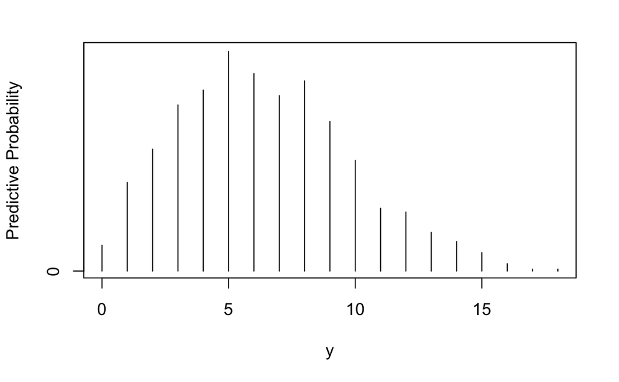

```r
freq = table(y) # save the frequency
ys = as.integer(names(freq))  # obtain the indexin values of table (observation of y)
predprob = freq/sum(freq)  # make them prob (normalize)
plot(ys, predprob, type="h", xlab = "y", ylab = "Predictive Probability")
```

`discint`: summarize the discrete predictive distribution by an interval that covers at least $x$%. Here we summarize for 90%.

```r
dist = cbind(ys, predprob)
rownames(dist) <- NULL
dist
```

```
      ys predprob
 [1,]  0    0.014
 [2,]  1    0.048
 [3,]  2    0.066
 [4,]  3    0.090
 [5,]  4    0.098
 [6,]  5    0.119
 [7,]  6    0.107
 [8,]  7    0.095
 [9,]  8    0.103
[10,]  9    0.081
[11,] 10    0.060
[12,] 11    0.034
[13,] 12    0.032
[14,] 13    0.021
[15,] 14    0.016
[16,] 15    0.010
[17,] 16    0.004
[18,] 17    0.001
[19,] 18    0.001
```

Output of `discint` is

- prob: exact covering prob
- set: credible set

```r
covprob = 0.9 # covering prob
discint(dist,covprob)
```

```
$prob
[1] 0.901

$set
 [1]  1  2  3  4  5  6  7  8  9 10 11
```

**Observation**

Here we see that $\tilde y$ can fall into {1, 2, 3, 4, 5, 6, 7, 8, 9, 10, 11} with prob 0.901. In other words, let the prop of long sleepers $\tilde y/20$, then the prob of this sample prop fall into $[1/20, 11/20]$ is 90.1%. The interval is much larger than population proportion $p$. Because the prediction of future sample proportion contains two uncertainties: population proportion $p$ and the binomial uncertainty for $\tilde y$.